# Interaction maps from incompletely dissociated primary tissue

Jason T. Serviss and Martin F. Enge

30 August 2016

## Introduction

Advances in single-cell biology has enabled us to investigate isolated single cells at an unprecedented resolution. Current methods can measure subtle changes in cell state, revealing specialized minor subpopulations within a cell type. However, functional characterization of such subpopulations is still challenging. A promising approach to untangling functional characterization is spatial transcriptomics, where genomewide measurements of gene expression are enriched with spatial attributes. Such approaches allow us to determine the relative positions of cell subpopulations. Unfortunately, current spatial transcriptomic approaches suffer either from problems with sensitivity, are limited to a restricted panel of genes, or the spatial attributes are of low resolution.  
In order to deconvolute the cell connectome, we sort multiplets of incompletely dissociated cells along with single cells from the same sample. The single cells provide a set of blueprints of possible subcell types, and subsequently we use swarm optimization approaches to infer the composition of multiplets. Using this method we can measure the composition of a very large number of multiplets onto a lattice consisting of subcell types of arbitrary complexity.

## Package summary

To accomplish these end-points an software package based on the R programming language has been deveolped named “*sp*atial *s*ingle *c*ell *RNA seq*” or **sp.scRNAseq**. The package works in 3 seperate stages which are described below:

1. A spCounts object is made by providing singlet and multuplet exprssion data.
2. The number of cell types present in the tissue is determined by running tSNE on the singlet expression profiles.
3. Swarm optimization is then used to deconvolute the multuplets, providing a map of cell-cell interactions.

Below we will demonstrate the sp.scRNAseq packages functionality and, in parallel, describe and show results from the testing of the package on *in silico* and biological data.

## Synthetic data testing of multuplet deconvolution using swarm optimization

```r
#load spatial scRNAseq testing package
library(sp.scRNAseqTesting)
```

### Singlets tSNE

After the data was generated, tSNE was run to view the clusering of the singlets and classify them into cell types. The results from the tSNE, plotted below, indicate that each cell clusters well within it’s cell type and that no overlap exists between groups of cell types. This represents the “ideal” situation and gives us a easy starting point to understand if swarm optimization may be an appropriate method to use even with less “well behaved” datasets.

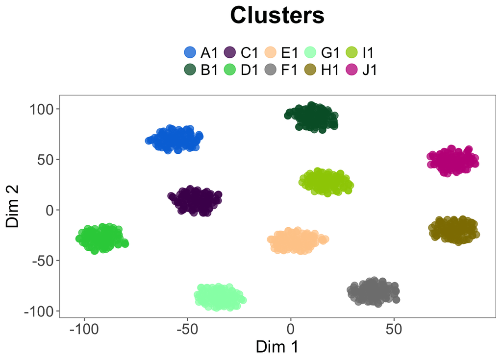

```r
s <- grepl("^s", colnames(syntheticDataTest))
cObjSng <- syntheticDataTest[,s]
cObjMul <- syntheticDataTest[,!s]

p <- spPlot(syntheticDataUnsupervised, cObjSng, type="clusters")
p
```

```r
ggsave(p, file="~/Github/sp.scRNAseqTesting/inst/connectionsTest/syntheticTestUnsupervised.pdf", device=cairo_pdf)
```

Figure 1. Unsupervised clustering of synthetic data singlets.

In the next, step swarm optimization was then evaluated as a method to deconvolute the multuplets, thus producing a cell-cell interaction map or “connectome”. To test this we generated multuplets based on the results of the post-tSNE classifications of the singlets. For example, to generate a multuplet representing the A1 and B1 group, one cell was picked from each group and the mean for each gene was calculated. Within the synthetic dataset multuplets were generated for all possible combinations of singlets using 2, 3, or 4 cells resulting in a total of 385 multuplets. We then picked 15 of these multuplets according to a specific number of connections desired between cell types (see table below). The swarm optimization was then tested using the spSwarm function . Due to the fact that we know which singlets were used to produce each multuplet and, therefore, which connections we expect, we can then measure the accuracy of the swarm optimization output.

### Results synthetic data

```r
syntheticDataTable
```

| from/to | A1 | B1 | C1 | D1 | E1 | F1 | G1 | H1 | I1 | J1 |
| --- | --- | --- | --- | --- | --- | --- | --- | --- | --- | --- |
| A1 | 1 | 1 | 1 | 0 | 0 | 2 | 0 | 0 | 1 | 0 |
| B1 | 0 | 0 | 1 | 0 | 1 | 3 | 1 | 2 | 2 | 0 |
| C1 | 0 | 0 | 0 | 1 | 3 | 3 | 1 | 1 | 3 | 1 |
| D1 | 0 | 0 | 0 | 0 | 1 | 1 | 2 | 0 | 0 | 1 |
| E1 | 0 | 0 | 0 | 0 | 0 | 1 | 1 | 2 | 2 | 2 |
| F1 | 0 | 0 | 0 | 0 | 0 | 1 | 2 | 1 | 3 | 1 |
| G1 | 0 | 0 | 0 | 0 | 0 | 0 | 0 | 0 | 0 | 1 |
| H1 | 0 | 0 | 0 | 0 | 0 | 0 | 0 | 0 | 0 | 1 |
| I1 | 0 | 0 | 0 | 0 | 0 | 0 | 0 | 0 | 0 | 1 |

Table 1. Expected connections in the synthetic multuplets.

Below we can see the network plot of the resulting connections detected after multuplet deconvloution. The singlets are clustered according to the previous tSNE results (small dots), the mean for each singlet classification group is represented by the large dots, and the detected interactions between groups (lines), and the number of interactions detected, or edge weights, are represented in the line thickness. Close inspection reveils that the detected connections mirror the expected connections in the table above.

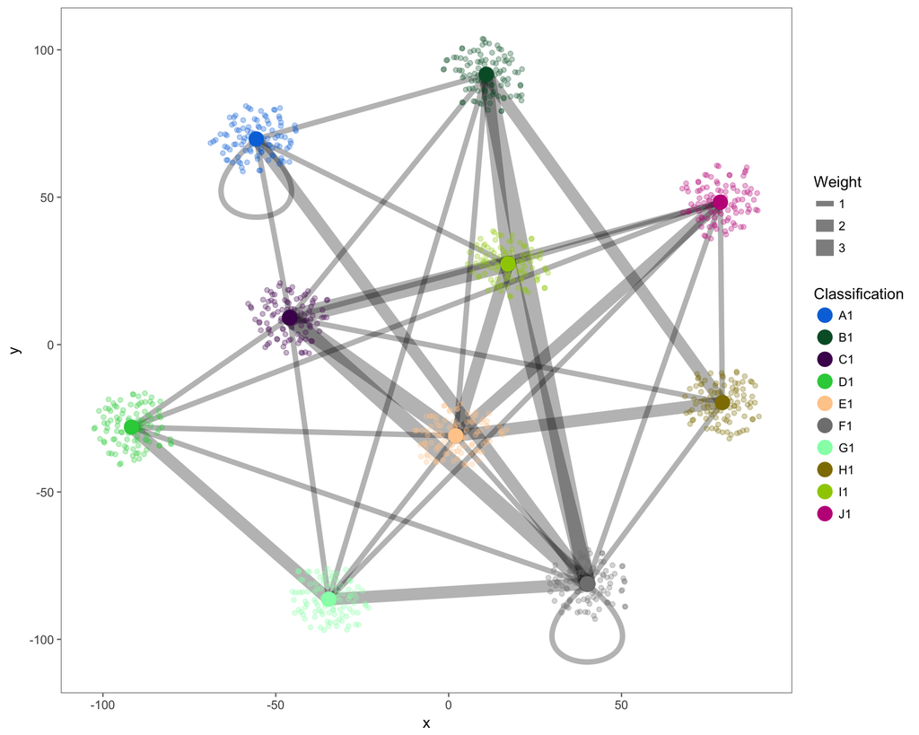

```r
edge.cutoff <- 1/10.5
min.pval <- 1
min.num.edges <- 1

#plot results
p <- spPlot(
    syntheticDataSwarm,
    syntheticDataUnsupervised,
    cObjSng,
    layout="tsne",
    loop=TRUE,
    edge.cutoff=edge.cutoff,
    min.pval=min.pval,
    min.num.edges=min.num.edges
)
p
```

```r
ggsave(p, file="~/Github/sp.scRNAseqTesting/inst/connectionsTest/syntheticTestSwarm.pdf", device=cairo_pdf)
```

Figure 2. Newtork graph of the deteced multuplets in the synthetic data.

To view the results in a easier manner, the heatmap below shows the real vs detected connections with the number of connections represented as the heatmap’s cell colors. The fact that all of the connections lay on a diagnal through the plot indicates that the swarm optimization method had a 100% sucess rate.

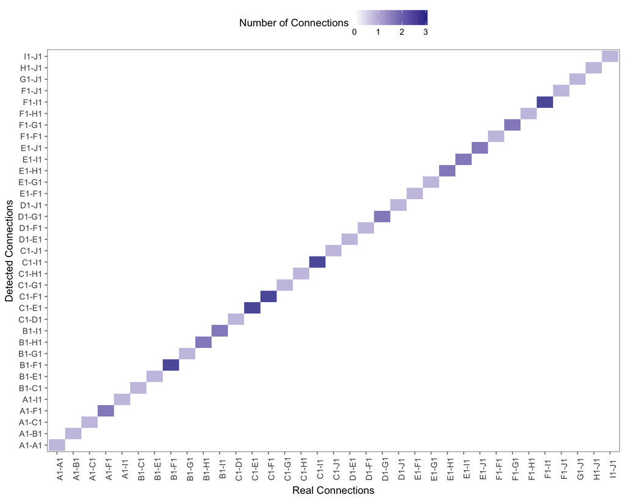

```r
detected <- spSwarmPoisson(syntheticDataSwarm, edge.cutoff = edge.cutoff, min.pval=min.pval, min.num.edges=min.num.edges)
real <- as.data.frame(syntheticDataTable)

d <- data.frame(
    real=sort(rep(paste(real$from, real$to, sep="-"), real$Freq)),
    detected=sort(rep(paste(detected$from, detected$to, sep="-"), detected$weight))
)

table <- as.data.frame(table(d))

p <- ggplot(table, aes(x=real, y=detected, fill=Freq))+
    geom_tile(alpha=0.85)+
    theme_few()+
    scale_fill_gradient2()+
    theme(
        axis.text.x=element_text(angle=90),
        legend.position="top"
    )+
    labs(
        x="Real Connections",
        y="Detected Connections",
        fill="Number of Connections"
    )
p
```

```r
ggsave(p, file="~/Github/sp.scRNAseqTesting/inst/connectionsTest/syntheticTestResults.pdf", device=cairo_pdf)
```

Figure 3. Real vs deteced connections in the synthetic data multuplets.

## Expression data testing of multuplet deconvolution using swarm optimization

### Expression data tSNE

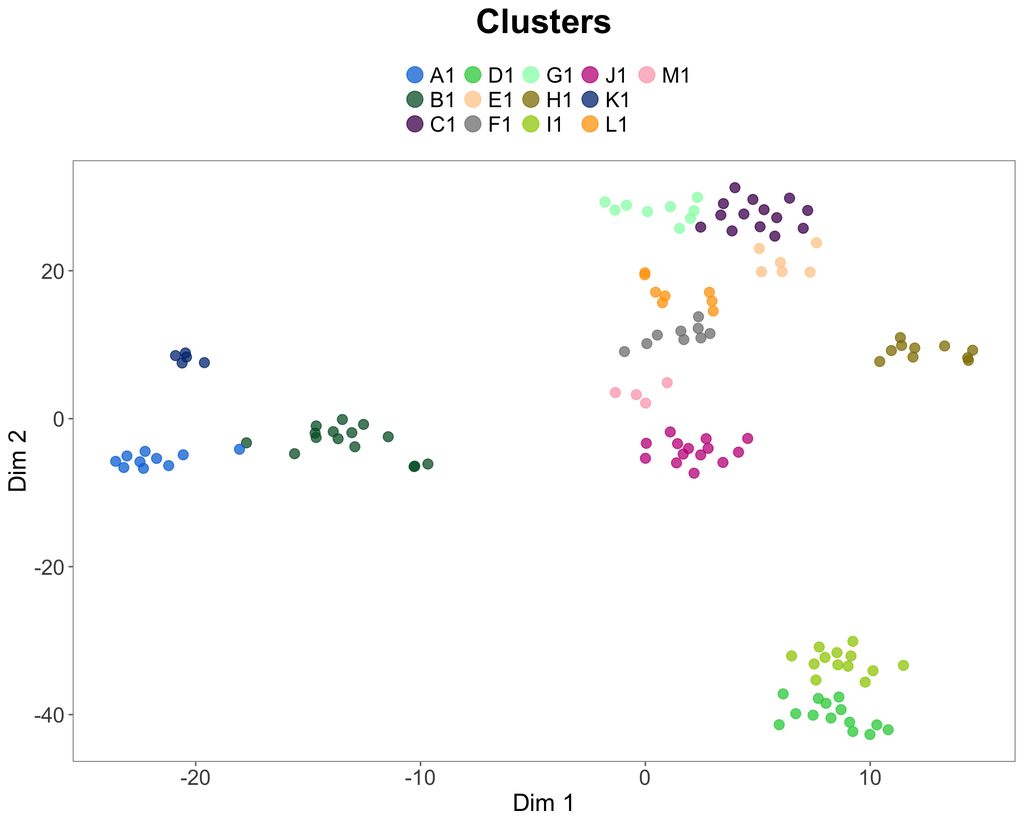

```r
#load test data
s <- grepl("^s", colnames(expressionTestData))
cObjSng <- expressionTestData[,s]
cObjMul <- expressionTestData[,!s]

p <- spPlot(expressionTestUnsupervised, cObjSng, type="clusters")
p
```

```r
ggsave(p, file="~/Github/sp.scRNAseqTesting/inst/connectionsTest/expressionTestUnsupervised.pdf", device=cairo_pdf)
```

Figure 4. Unsupervised clustering of the expression data singlets.

### Expression data results

```r
expressionTestTable
```

| from/to | B1 | C1 | D1 | E1 | F1 | G1 | H1 | I1 | J1 | K1 | L1 | M1 |
| --- | --- | --- | --- | --- | --- | --- | --- | --- | --- | --- | --- | --- |
| A1 | 2 | 1 | 4 | 2 | 2 | 1 | 1 | 3 | 2 | 2 | 0 | 1 |
| B1 | 0 | 3 | 2 | 4 | 1 | 2 | 2 | 4 | 1 | 1 | 4 | 0 |
| C1 | 0 | 0 | 3 | 3 | 2 | 2 | 2 | 1 | 1 | 1 | 2 | 1 |
| D1 | 0 | 0 | 0 | 6 | 4 | 3 | 1 | 2 | 4 | 2 | 1 | 3 |
| E1 | 0 | 0 | 0 | 0 | 2 | 1 | 1 | 4 | 4 | 1 | 2 | 2 |
| F1 | 0 | 0 | 0 | 0 | 0 | 1 | 3 | 1 | 5 | 3 | 1 | 1 |
| G1 | 0 | 0 | 0 | 0 | 0 | 0 | 3 | 1 | 2 | 3 | 1 | 2 |
| H1 | 0 | 0 | 0 | 0 | 0 | 0 | 0 | 3 | 2 | 2 | 1 | 0 |
| I1 | 0 | 0 | 0 | 0 | 0 | 0 | 0 | 0 | 2 | 0 | 2 | 1 |
| J1 | 0 | 0 | 0 | 0 | 0 | 0 | 0 | 0 | 0 | 3 | 1 | 2 |
| K1 | 0 | 0 | 0 | 0 | 0 | 0 | 0 | 0 | 0 | 0 | 2 | 2 |
| L1 | 0 | 0 | 0 | 0 | 0 | 0 | 0 | 0 | 0 | 0 | 0 | 1 |

Table 2. Expected connections in the expression data multuplets

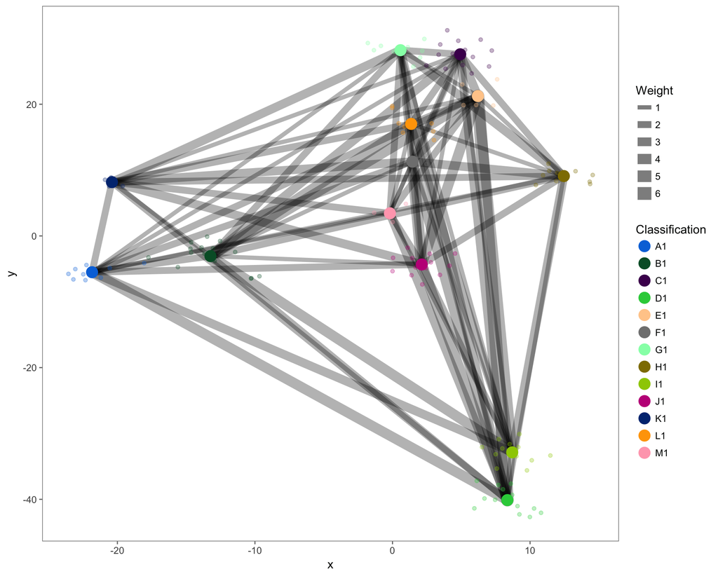

```r
edge.cutoff <- 1/12
min.pval <- 1
min.num.edges <- 1

#plot results
p <- spPlot(
    expressionTestSwarm,
    expressionTestUnsupervised,
    cObjSng,
    layout="tsne",
    loop=TRUE,
    edge.cutoff=edge.cutoff,
    min.pval=min.pval,
    min.num.edges=min.num.edges
)
p
```

```r
ggsave(p, file="~/Github/sp.scRNAseqTesting/inst/connectionsTest/expressionTestSwarm.pdf", device=cairo_pdf)
```

Figure 5. Network graph of the connections detected in the expression data multuplets.

Plotting the results in the heatmap format indicate that swarm optimization is, again, able to deconvolute the multuplets within this dataset with a 100% sucess rate.

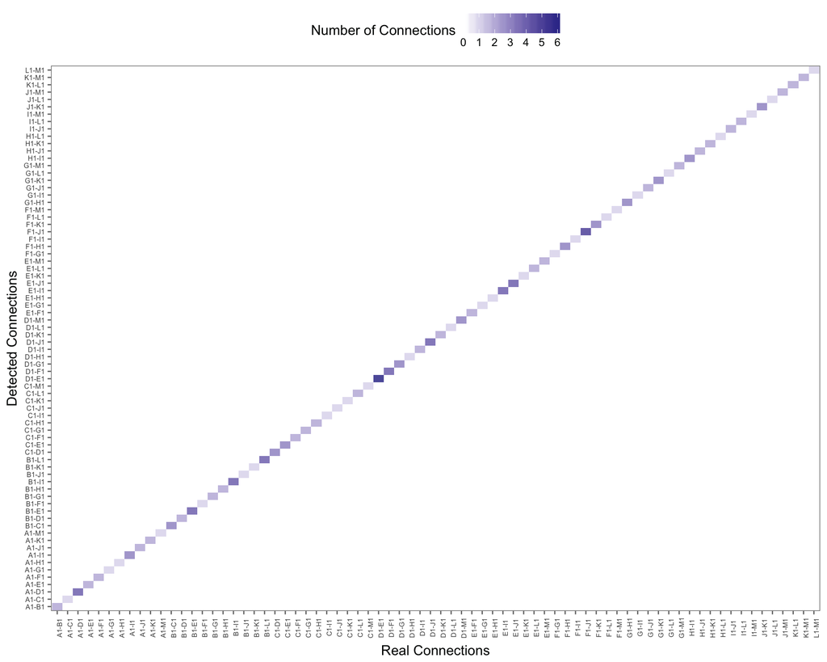

```r
detected <- spSwarmPoisson(expressionTestSwarm, edge.cutoff = edge.cutoff, min.pval=min.pval, min.num.edges=min.num.edges)
real <- as.data.frame(expressionTestTable)

d <- data.frame(
    real=sort(rep(paste(real$from, real$to, sep="-"), real$Freq)),
    detected=sort(rep(paste(detected$from, detected$to, sep="-"), detected$weight))

)

table <- as.data.frame(table(d))

p <- ggplot(table, aes(x=real, y=detected, fill=Freq))+
    geom_tile(alpha=0.85)+
    theme_few()+
    scale_fill_gradient2()+
    theme(
        axis.text.x=element_text(angle=90),
        axis.text=element_text(size=6),
        legend.position="top"
    )+
    labs(
        x="Real Connections",
        y="Detected Connections",
        fill="Number of Connections"
    )
p
```

```r
ggsave(p, file="~/Github/sp.scRNAseqTesting/inst/connectionsTest/expressionTestResults.pdf")
```

Figure 6. Real vs detected connections in expression data multuplets.

## Experimental data testing of multuplet deconvolution using swarm optimization

Next, we used the sp.scRNAseq package on experimental data where both singlets and multuplets from fetal pancreatic tissue were physically isolated, via FACS sorting, previous to scRNAseq. The dataset includes 131 singlets and 69 multuplets.

### Experimental data ercc

```r
#load test data
data(expData)

#expData is already a spCounts object
cObj <- expData
```

```r
spPlot(cObj, type="ercc")
```

[output not shown]

### Experimental data markers

#### INS THY1

```r
markers <- c("INS", "THY1")
spPlot(cObj, type="markers", markers=markers)
```

[output not shown]

#### INS GCG

```r
markers <- c("INS", "GCG")
spPlot(cObj, type="markers", markers=markers)
```

[output not shown]

#### FLT1 THY1

```r
markers <- c("FLT1", "THY1")
spPlot(cObj, type="markers", markers=markers)
```

[output not shown]

#### EPCAM THY1

```r
markers <- c("EPCAM", "THY1")
spPlot(cObj, type="markers", markers=markers)
```

[output not shown]

#### PROM1 THY1

```r
markers <- c("PROM1", "THY1")
spPlot(cObj, type="markers", markers=markers)
```

[output not shown]

#### PROM1 INS

```r
markers <- c("PROM1", "INS")
spPlot(cObj, type="markers", markers=markers)
```

[output not shown]

### Experimental data tSNE

```r
#run unsupervised learning
uObj <- spUnsupervised(cObj, max=2000, max_iter=20000)
```

```r
#plot unsupervised results; cluster plot
spPlot(uObj, type="clusters")
```

[output not shown]

To relate the resulting tSNE-based classifications to previously known cell identities we further plotted the tSNE results showing expression levels (log 2 normalized counts) of several well known cell surface markers. Note that the dot colors in the plot represent the expression levels.

```r
#plot unsupervised results; markers plot
markers <- c("EPCAM", "THY1", "FLT1", "INS", "GCG", "NEUROG3", "PROM1", "SST", "PRSS1")
spPlot(uObj, type="markers", markers=markers)
```

[output not shown]

### Experimental data results

```r
#run pySwarm
result3 <- spSwarm(cObj, uObj, maxiter=10, swarmsize=250, cores=8)
```

```r
#plot results
spPlot(result3)
```

[output not shown]

## Conclusions

## Functions

### syntheticDataTest

#### .syntheticTestData

(wraps .syntheticSinglets and .syntheticMultuplits into one function)

#### .syntheticSinglets

#### .syntheticMultuplets

### expressionDataTest

#### .expressionTestData

#### .assemble

### experimentalDataTest